# Statistical Rethinking

# 11. 神は整数に釘を打った

集約された二項分布について

# 13. 記憶を伴ったモデル

多くの統計モデルは前向性健忘である。 モデルは一つのクラスターから別のクラスターに移動し、それぞれのパラメーターを推定し以前のクラスターについて忘れている。 変わりにクラスターの集団を学習しながら、それぞれのクラスターを同時に学習する必要がある。 ２つのカフェに行くとき、最初のカフェの待ち時間を２つ目のカフェの事前分布にすることができる。 この場合、各カフェのパラメータとカフェの母集団のパラメータを推定していることになる。 この章では、マルチレベルモデルについて見ていく。以下の利点がある。 (1)繰り替えしサンプリングによる推定の改善 (2)サンプリングにおけるアンバランスのための推定の改善 (3)分散の推定 (4)平均を避けて、分散を保持する。

マルチレベルアプローチのコストとして、 (1)クラスターの特性がどのような分布から生じるのかを定義する必要がある。 (2)新しい推定の問題が生じること (3)データの異なるレベルで予測を行うため、理解が難しいことである。

リシンキング: マルチレベルは階層や混合効果と同意語であり、パラメータの種類はランダム効果として知られている。

## 具体例: マルチレベルなおたまじゃくし

クサガエルのおたまじゃくしの死亡率を例にする。

```r
library(rethinking)
data(reedfrogs)
d <- reedfrogs
str(d)
```

```
'data.frame':   48 obs. of  5 variables:
 $ density : int  10 10 10 10 10 10 10 10 10 10 ...
 $ pred    : Factor w/ 2 levels "no","pred": 1 1 1 1 1 1 1 1 2 2 ...
 $ size    : Factor w/ 2 levels "big","small": 1 1 1 1 2 2 2 2 1 1 ...
 $ surv    : int  9 10 7 10 9 9 10 9 4 9 ...
 $ propsurv: num  0.9 1 0.7 1 0.9 0.9 1 0.9 0.4 0.9 ...
```

各行が水槽であり、タンクがクラスタ変数の具体例とする。 繰り返しの測定とクラスタ間における不均質性がある。

マルチレベルは各水槽の切片と水槽間の分散を同時に推定する。これはVarying interceptsモデルである。

下記は正規化事前分布を用いた各水槽のオタマジャクシの死亡率予測モデルである。

Si ∼ Binomial(Ni, pi) logit(pi) = αtank[i] αj ∼ Normal(0, 1.5) for j = 1..48

```r
# make the tank cluster variable d$tank <- 1:nrow(d)
d$tank <- 1:nrow(d)
dat <- list(
S = d$surv,
    N = d$density,
    tank = d$tank )

m13.1 <- ulam(
alist(
S ~ dbinom( N , p ) , logit(p) <- a[tank] , a[tank] ~ dnorm( 0 , 1.5 )
), data=dat , chains=4 , log_lik=TRUE )
```

[output not shown]

[output cut: 582 more lines]

```
Chain 4 Iteration: 200 / 1000 [ 20%]  (Warmup)
Chain 4 Iteration: 300 / 1000 [ 30%]  (Warmup)
Chain 4 Iteration: 400 / 1000 [ 40%]  (Warmup)
Chain 4 Iteration: 500 / 1000 [ 50%]  (Warmup)
Chain 4 Iteration: 501 / 1000 [ 50%]  (Sampling)
Chain 4 Iteration: 600 / 1000 [ 60%]  (Sampling)
Chain 4 Iteration: 700 / 1000 [ 70%]  (Sampling)
Chain 4 Iteration: 800 / 1000 [ 80%]  (Sampling)
Chain 4 Iteration: 900 / 1000 [ 90%]  (Sampling)
Chain 4 Iteration: 1000 / 1000 [100%]  (Sampling)
Chain 4 finished in 0.1 seconds.

All 4 chains finished successfully.
Mean chain execution time: 0.2 seconds.
Total execution time: 1.3 seconds.
```

事後分布precis(m13.1,depth=2)を調べると、それぞれの水槽の48の切片があることが分かる。各水槽の生存率を得るためには一つの値を使って、ロジスティック変換をすればいい。

ここからマルチレベルモデルを行う。

Si ∼ Binomial(Ni, pi) logit(pi) = αtank[i] αj ∼ Normal(α ̄, σ) α ̄ ∼ Normal(0, 1.5) σ ∼ Exponential(1)

水槽の切片のための事前分布は(α ̄, σ)の関数となっている。

第1レベルでは、結果は S であり、パラメータはベクトル α である。 第2レベルでは、目的ヘンス変数は切片パラメータαのベクトルです。 パラメータはα ̄とσで、それらの事前分布はα ̄ ∼ Normal(0, 1.5) と σ ∼ Exponential(1)です

(α ̄, σ)はハイパーパラメータであり、それらの事前分布はハイパー事前分布と呼ぶ。

再考: ガウス分布を用いる理由は慣習であり、著者の答えは分布が対称になるのはエントロピーの最大になるからである。

```r
m13.2 <- ulam( alist(
  S ~ dbinom( N , p ) ,
  logit(p) <- a[tank] ,
  a[tank] ~ dnorm( a_bar , sigma ) ,
  a_bar ~ dnorm( 0 , 1.5 ) ,
  sigma ~ dexp( 1 )
), data=dat , chains=4 , log_lik=TRUE )
```

[output not shown]

[output cut: 88 more lines]

```
Chain 2 Iteration: 300 / 1000 [ 30%]  (Warmup)
Chain 2 Iteration: 400 / 1000 [ 40%]  (Warmup)
Chain 2 Iteration: 500 / 1000 [ 50%]  (Warmup)
Chain 2 Iteration: 501 / 1000 [ 50%]  (Sampling)
Chain 2 Iteration: 600 / 1000 [ 60%]  (Sampling)
Chain 2 Iteration: 700 / 1000 [ 70%]  (Sampling)
Chain 2 Iteration: 800 / 1000 [ 80%]  (Sampling)
Chain 2 Iteration: 900 / 1000 [ 90%]  (Sampling)
Chain 2 Iteration: 1000 / 1000 [100%]  (Sampling)
Chain 2 finished in 0.2 seconds.
Chain 3 Iteration:   1 / 1000 [  0%]  (Warmup)
Chain 3 Iteration: 100 / 1000 [ 10%]  (Warmup)
Chain 3 Iteration: 200 / 1000 [ 20%]  (Warmup)
Chain 3 Iteration: 300 / 1000 [ 30%]  (Warmup)
Chain 3 Iteration: 400 / 1000 [ 40%]  (Warmup)
```

[output not shown]

```
Chain 3 Iteration: 500 / 1000 [ 50%]  (Warmup)
Chain 3 Iteration: 501 / 1000 [ 50%]  (Sampling)
Chain 3 Iteration: 600 / 1000 [ 60%]  (Sampling)
Chain 3 Iteration: 700 / 1000 [ 70%]  (Sampling)
Chain 3 Iteration: 800 / 1000 [ 80%]  (Sampling)
Chain 3 Iteration: 900 / 1000 [ 90%]  (Sampling)
Chain 3 Iteration: 1000 / 1000 [100%]  (Sampling)
Chain 3 finished in 0.2 seconds.
Chain 4 Iteration:   1 / 1000 [  0%]  (Warmup)
Chain 4 Iteration: 100 / 1000 [ 10%]  (Warmup)
Chain 4 Iteration: 200 / 1000 [ 20%]  (Warmup)
Chain 4 Iteration: 300 / 1000 [ 30%]  (Warmup)
Chain 4 Iteration: 400 / 1000 [ 40%]  (Warmup)
Chain 4 Iteration: 500 / 1000 [ 50%]  (Warmup)
Chain 4 Iteration: 501 / 1000 [ 50%]  (Sampling)
Chain 4 Iteration: 600 / 1000 [ 60%]  (Sampling)
Chain 4 Iteration: 700 / 1000 [ 70%]  (Sampling)
Chain 4 Iteration: 800 / 1000 [ 80%]  (Sampling)
Chain 4 Iteration: 900 / 1000 [ 90%]  (Sampling)
Chain 4 Iteration: 1000 / 1000 [100%]  (Sampling)
Chain 4 finished in 0.2 seconds.

All 4 chains finished successfully.
Mean chain execution time: 0.2 seconds.
Total execution time: 1.5 seconds.
```

このモデルは50のパラメータのための事後分布を生み出す。サンプル全体の切片α ̄と水槽α 間の標準偏差、48の水槽の切片である。

ここで、WAICで比較を行う。

```r
compare( m13.1 , m13.2 )
```

|  | WAIC | SE | dWAIC | dSE | pWAIC | weight |
| --- | --- | --- | --- | --- | --- | --- |
| m13.2 | 199.0 | 7.25 | 0.0 | NA | 20.5 | 1 |
| m13.1 | 214.1 | 4.79 | 15.1 | 4.04 | 25.4 | 0 |

マルチレベルモデルは、21の有効パラメータを持ち、実際のパラメータよりも28少ない、また、混合モデルよりも少ないパラメーターしかもたない。

適応正則の効果を見るためにマルチレベルモデルをグラフにする。

```r
# extract Stan samples
post <- extract.samples(m13.2)
# compute mean intercept for each tank
# also transform to probability with logistic
d$propsurv.est <- logistic( apply( post$a , 2 , mean ) )
# display raw proportions surviving in each tank
plot( d$propsurv , ylim=c(0,1) , pch=16 , xaxt="n" ,
    xlab="tank" , ylab="proportion survival" , col=rangi2 )
axis( 1 , at=c(1,16,32,48) , labels=c(1,16,32,48) )
```

```r
# overlay posterior means
points( d$propsurv.est )
# mark posterior mean probability across tanks
abline( h=mean(inv_logit(post$a_bar)) , lty=2 )
```

```r
# draw vertical dividers between tank densities
abline( v=16.5 , lwd=0.5 )
abline( v=32.5 , lwd=0.5 )
```

```r
text( 8 , 0 , "small tanks" )
text( 16+8 , 0 , "medium tanks" )
```

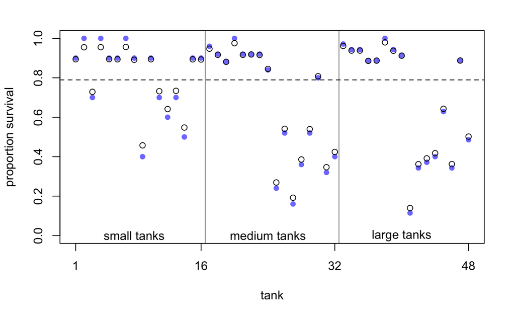

```r
text( 32+8 , 0 , "large tanks" )
```

x軸がそれぞれの水槽であり、y軸が水槽の生存率である。破線は生存率の平均である。 生存の経験的な割合を青い点で、マルチレベルによるパラメーターを黒の輪で表示した。

(1)マルチレベルの推定のほうが、行の経験的な推定よりも破線に近い。この現象を 縮小(Shrinkage)という。 (2)小型水槽の方において、さらに縮小していることが見られる。 (3)青い点が破線から離れるほど、縮小が大きくなる。 これらの効果はクラスター間において情報のプーリングによって生じる。

推定される生存率の分布は、事後分布からサンプリングすることによって可視化することができる。

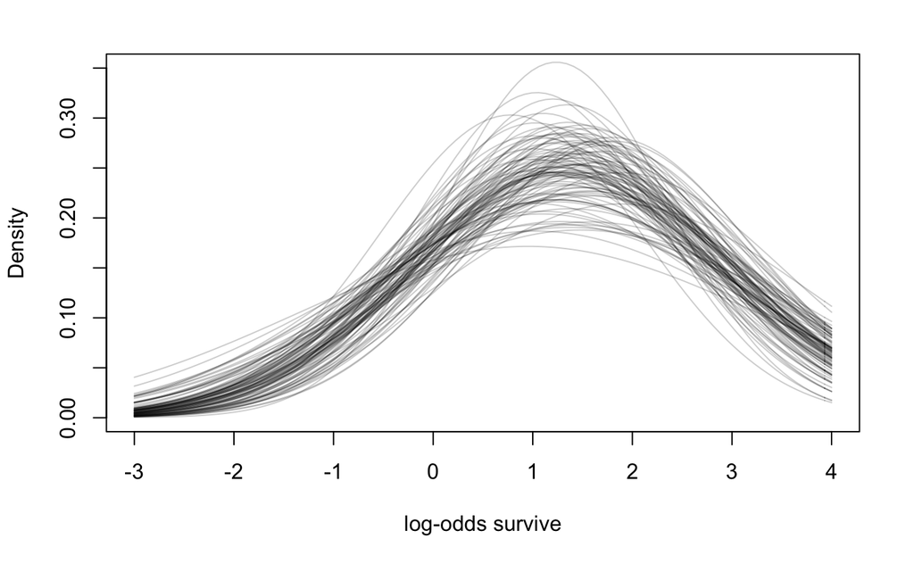

```r
# show first 100 populations in the posterior
plot( NULL , xlim=c(-3,4) , ylim=c(0,0.35) ,
xlab="log-odds survive" , ylab="Density" )
for ( i in 1:100 )
  curve( dnorm(x,post$a_bar[i],post$sigma[i]) , add=TRUE, col=col.alpha("black",0.2) )
```

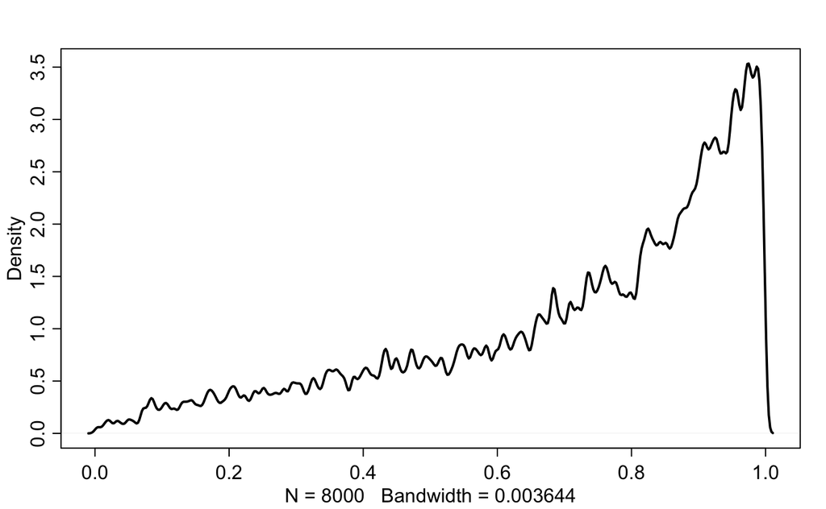

```r
# sample 8000 imaginary tanks from the posterior distribution
sim_tanks <- rnorm( 8000 , post$a_bar , post$sigma )
# transform to probability and visualize
dens( inv_logit(sim_tanks) , lwd=2 , adj=0.1 )
```

## 13.2 異なる効果と過少適合と過剰適合のトレードオフ